# Fill in missing values on LotFrontage

This is a supporting notebook to showcase the data preparation for the first model for the Kaggle House Pricing competition

The missing data plot on the original data set shows that close to 16% of the data has missing LotFrontage.

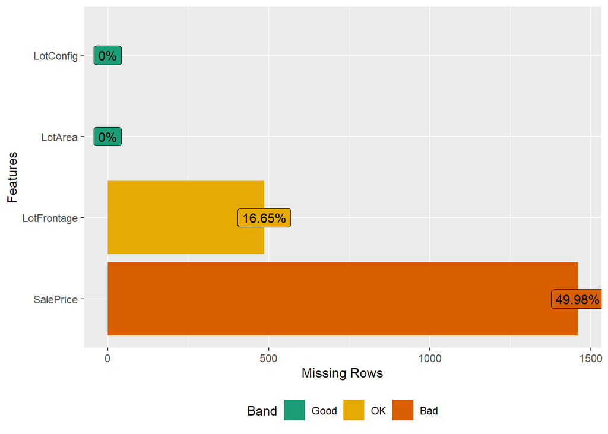

We fit a Gamma model to this with a log-link due to the skew nature of LotFrontage. We use the area of the lot as well as the lot’s configuration or shape details. Not all fitted parameters are significantly different from 0, which we won’t address this time around as this model is not used for factor inference and we just want a prediction

The R-squared value is close to 40%. This is hardly amazing but is a far improvement over using a 0 for all missing values.

```
##
## Call:
## glm(formula = LotFrontage ~ LotArea + LotConfig, family = Gamma(link = "log"),
##     data = data_ltz)
##
## Coefficients:
##                      Estimate   Std. Error t value            Pr(>|t|)
## (Intercept)       3.940349658  0.014461903 272.464 <0.0000000000000002 ***
## LotArea           0.000044173  0.000000778  56.775 <0.0000000000000002 ***
## LotConfigCulDSac -0.525472928  0.028689980 -18.316 <0.0000000000000002 ***
## LotConfigFR2     -0.317620716  0.032508339  -9.770 <0.0000000000000002 ***
## LotConfigFR3     -0.032915598  0.077900462  -0.423               0.673
## LotConfigInside  -0.164413174  0.013334274 -12.330 <0.0000000000000002 ***
## ---
## Signif. codes:  0 '***' 0.001 '**' 0.01 '*' 0.05 '.' 0.1 ' ' 1
##
## (Dispersion parameter for Gamma family taken to be 0.05922707)
##
##     Null deviance: 285.33  on 2432  degrees of freedom
## Residual deviance: 177.26  on 2427  degrees of freedom
## AIC: 20915
##
## Number of Fisher Scoring iterations: 19
```

```
## fitting null model for pseudo-r2
```

```
##               llh           llhNull                G2          McFadden
## "-10450.39983108" "-11038.48898603" "  1176.17830990" "     0.05327624"
##              r2ML              r2CU
## "     0.38333366" "     0.38337759"
```

From the first actual vs predicted plot we can see there is a blowout. The value from the model is unlikely (600K feet). We will cap the result to Q3+k*IQR. The predicted value for LotFrontage is capped at 143 feet.

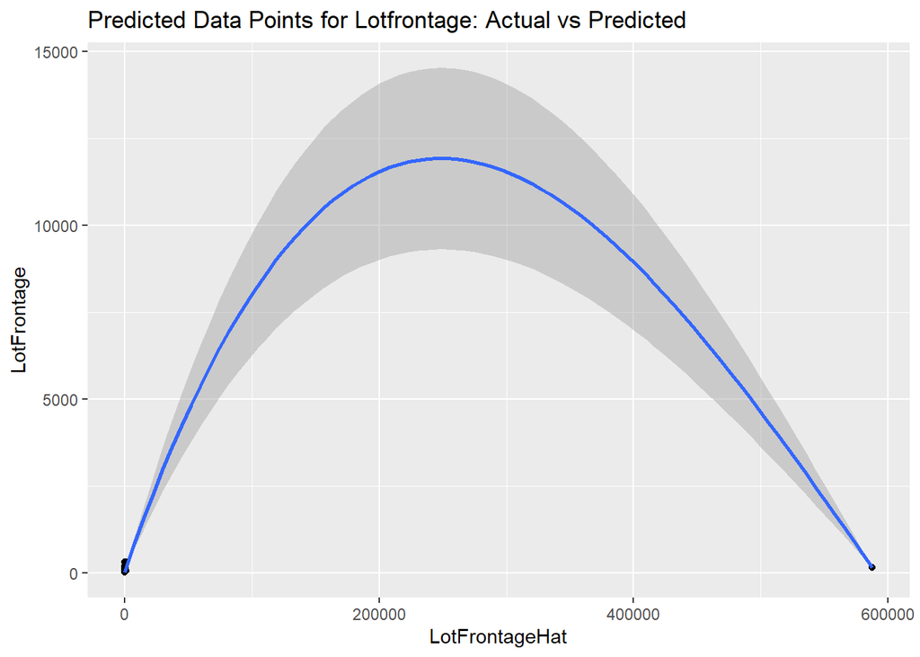

The cap in the predicted value shows the resulting predictions a little better.

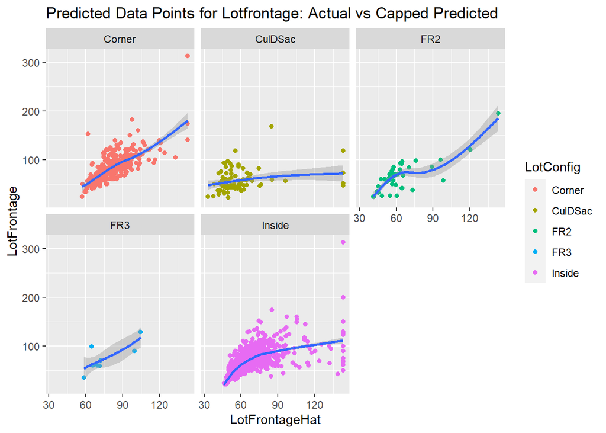

We only want to use the value of the imputation when the value is missing. Looking at the first few data lines of missing and non missing lines we see the imputation is correctly done for the newly created LotFrontageF variable.

We just need to sort out the decimals and we’re ready to use it in our modelling

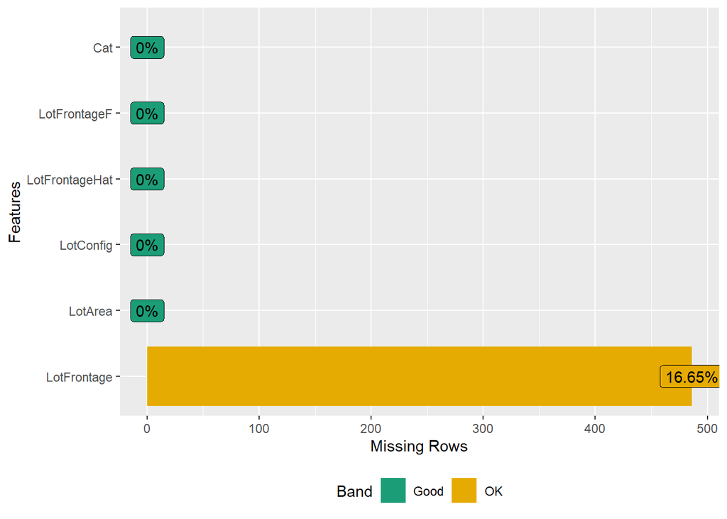

|  | LotFrontage | LotArea | LotConfig | LotFrontageHat | LotFrontageF | Cat |
| --- | --- | --- | --- | --- | --- | --- |
| 8 | NA | 10382 | Corner | 81.36590 | 81 | Impute |
| 13 | NA | 12968 | Inside | 77.38362 | 77 | Impute |
| 15 | NA | 10920 | Corner | 83.32274 | 83 | Impute |
| 17 | NA | 11241 | CulDSac | 49.97027 | 50 | Impute |
| 25 | NA | 8246 | Inside | 62.81469 | 63 | Impute |
| 32 | NA | 8544 | CulDSac | 44.35799 | 44 | Impute |

|  | LotFrontage | LotArea | LotConfig | LotFrontageHat | LotFrontageF | Cat |
| --- | --- | --- | --- | --- | --- | --- |
| 1 | 65 | 8450 | Inside | 63.38330 | 65 | Original |
| 2 | 80 | 9600 | FR2 | 57.21363 | 80 | Original |
| 3 | 68 | 11250 | Inside | 71.72831 | 68 | Original |
| 4 | 60 | 9550 | Corner | 78.42981 | 60 | Original |
| 5 | 84 | 14260 | FR2 | 70.29069 | 84 | Original |
| 6 | 85 | 14115 | Inside | 81.40542 | 85 | Original |

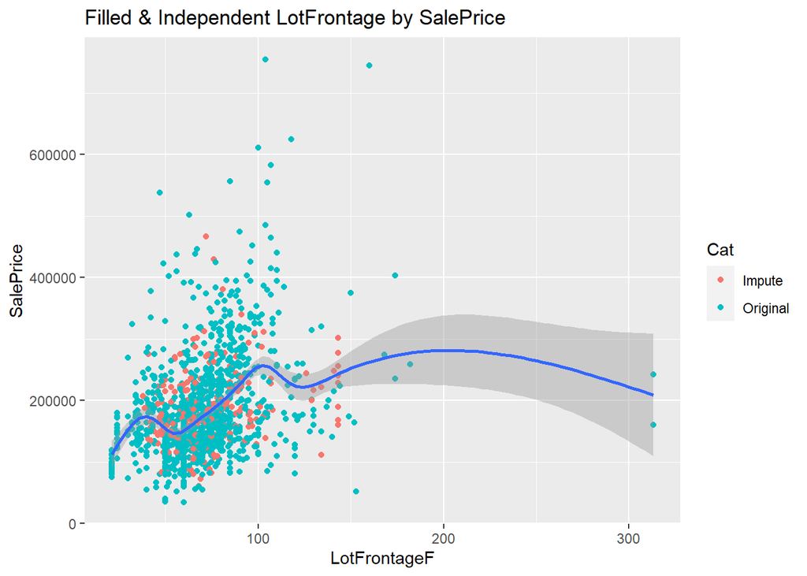